# Natalità tra Clima ed Economia:

### analisi dei fattori correlati

# Visione iniziale

L'idea nasce dalla curiosità di verificare se la natalità/fertilità e il riscaldamento globale siano correlati. Si sono quindi ricercate delle fonti da cui estrarre, tramite chiamate API, la media delle nascite annuali in Italia. La ricerca è stata difficoltosa, perché non è possibile avvalersi del sito ufficiale italiano: [www.api.gov.it](https://api.gov.it/it/), in quanto è riservato solo allo scambio dei dati in esso contenuti tra i vari enti pubblici. Dopo un'attenta ricerca è stato trovato il sito delle Nazioni Unite: [population.un.org](https://www.un.org/development/desa/pd/) da cui sono stati estratti i dati della natalità e fertilità. Mentre per quanto riguarda la temperatura globale è stata recuperata dal sito: [ourworldindata.org.](https://ourworldindata.org/)

## Rapporto tra natalità, fertilità e temperatura in Italia dagli anni 50 ad oggi:

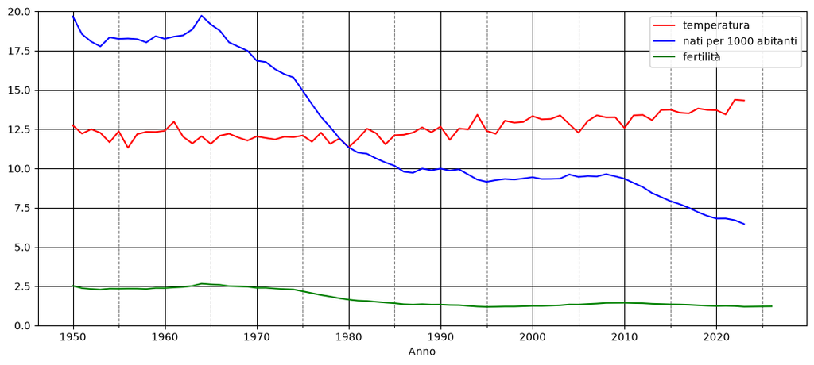

Dal grafico sembra emergere che non vi sia una correlazione significativa tra la temperatura e il tasso di natalità o fertilità.  
Mentre le nascite e la fertilità hanno un andamento simile.

## Rapporto tra le variazioni annuali tra natalità, fertilità e temperatura in Italia dagli anni 50 ad oggi:

Per avere una visione più dettagliata dei dati è stata calcolata la variazione dei dati di anno in anno per ogni elemento preso in considerazione (nascita/fertilità/temperatura).

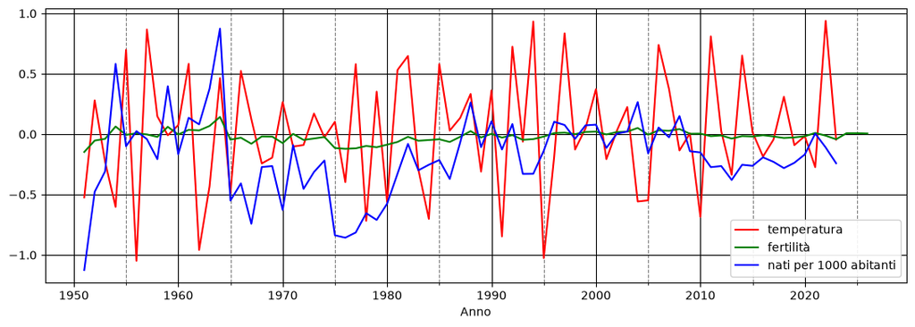

Qui notiamo chiaramente l'analogia tra l'andamento della fertilità e della natalità e come le stesse differiscano dalla variazione della temperatura media annuale.

# Evoluzione del progetto

Non trovando relazioni tra la temperatura media annuale Italiana e le nascite, si sono cercate altre possibili cause per la diminuzione delle stesse. Da una ricerca risulta che le cause principali per la diminuzione delle nascite dopo il baby boom del 1964 sono le seguenti:

- Fattori sociali e culturali:
  - Riduzione delle future madri.
  - Maggiore emancipazione femminile (ingresso delle donne nel mondo del lavoro).
  - La diffusione dei contraccettivi.
  - Posticipazione della genitorialità.
- Fattori economici:
  - Precarietà lavorativa.
  - Aumento dei costi della vita e degli immobili.
  - Carenza di politiche pubbliche di sostegno alla genitorialità.

Dopo aver individuato le possibili cause della diminuzione delle nascite, è stata svolta una ricerca di fonti pubbliche relative ai fattori economici, essendo gli unici quantificabili.

Sarebbe stato interessante analizzare il reddito medio dei cittadini italiani e/o il tasso di inflazione; tuttavia, non sono state individuate fonti pubbliche per accedere a questi dati.

L’unico dato disponibile e utilizzabile è risultato essere il prezzo medio delle abitazioni, reperito da una pubblicazione sul sito della Banca d’Italia: [Nominal housing prices in Italy 1927-2016](https://www.bancaditalia.it/statistiche/tematiche/stat-storiche/stat-storiche-economia/Housing_prices.zip?language_id=1) sulla base del quale è stato realizzato il grafico che segue.

## Rapporto tra natalità e prezzo medio delle abitazioni in Italia (al metro quadro) dagli anni 50 al 2016:

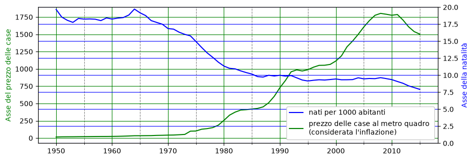

## Rapporto tra le variazioni annuali tra natalità e prezzo medio delle abitazioni (al metro quadro) in Italia dagli anni 50 al 2016:

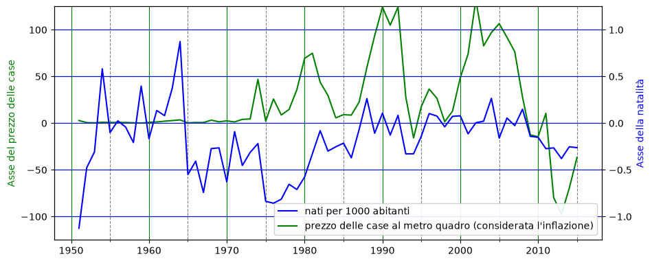

In questo grafico si può già notare una possibile correlazione tra le cause economiche e il calo delle nascite.

# Conclusioni

Le analisi sui dati economici Italiani risultano difficoltose a causa della scarsità delle fonti di dati contenenti informazioni antecedenti al 2000-2010. Questo progetto si è rivelato interessante in quanto ha esposto la mancata reperibilità di dati storici pubblici che potrebbero essere utili per numerose ricerche in vari ambiti.

# Fonti:

- Fonti utilizzate:
  - [Our World in data](https://ourworldindata.org/grapher/average-monthly-surface-temperature), dal quale sono stati estratti i dati sulla temperatura ([link diretto al .csv](https://ourworldindata.org/grapher/average-monthly-surface-temperature.csv)).
  - [Divisione per la popolazione delle Nazioni Unite](https://population.un.org), dal quale sono stati estratti i dati sulla natalità e sulla fertilità, accessibili tramite chiave api da richiedere.
  - [Banca d'italia](https://www.bancaditalia.it/statistiche/tematiche/stat-storiche/stat-storiche-economia/index.html), dal quale è stato scaricato un foglio excel contenente i dati sul prezzo medio al metro quadro delle case.
- Altre fonti (non utilizzate):
  - [Banca d'italia](https://www.bancaditalia.it/statistiche/tematiche/indagini-famiglie-imprese/bilanci-famiglie/documenti-storici/index.html): pubblicazioni relative al reddito degli Italiani.
  - [API del governo](https://api.gov.it/it/): accessibile solo da enti pubblici.
  - [Open meteo](https://open-meteo.com/): API gratuita contenente dati metereologici risalenti al 1940.
  - [Istat](https://www.istat.it/): Altro ente che mantiene dati demografici, però rivolto specificatamente all'Italia.